# Social Media Mining with R

A case study on Turkish Airlines

Sahban Tariq Malik  
Supervisor - Ayşe Çınar

13 June 2018

# Introduction

- Data mining is the process of extracting useful information from large set of any raw data.
- Text mining is a branch of data mining in which raw data is in the textual format.
- Social media mining is a branch of text mining in which social media data is used.
- R is a programming language with a statistical software environment used to analyze data efficiently.
- The study aims to extract useful information from Social Media textual data using R statistical software.

# Features of Textual Data

- Collection of Document
  - A collection of documents is a group of similar text-based documents.
  - The reviews of a tourism brand altogether become a collection of documents.
- Document
  - A collection of words that represents a unit within a document collection.
- Document Features
  - Character
  - Word
  - Term
  - Concepts

# Document Features

- Character
  - Characters are the building block of other higher-level semantic document features, i.e. words.
  - The characters include basic-level letters, numbers, special characters and even spaces.
- Word
  - This feature has more semantic richness than character.
  - It is more meaningful for text mining analysis than character.
  - A word in a document is also known as a linguistic token.
  - The process of representing a document in words is also known as tokenization
- Term
  - Multiword (n-gram) phrases are the terms that are extracted from the collection of documents.
  - Example: “They have a nice inflight entertainment system and the high speed Wi-Fi was free for Business Class and very reasonable for economy class”
    - “Business Class”
    - “Economy Class”
    - “Entertainment System”
- Concepts
  - More sophisticated feature, and therefore requires highly advanced text mining techniques.
  - For instance, a review of airline industry may not necessarily include the words “entertainment” or “aircraft” but these concepts are included.

# Social Media Mining

- Social media has been widely used as a major channel of communication.
- Allows users and businesses to connect and interact on a worldwide level.
- The most popular social media website, Facebook, has over one billion active members and more than 890 million active users everyday.
- According to Statista, TripAdvisor has become top ranked tourism website with 7 million listings for hotels, airlines, restaurants and attractions.
- There are over 460 million user opinions and reviews on the listings.
- Business enterprises can extract customer insights from user generate data in social media.
- The enormous social media data can play major role in modern business strategy making processes.
- since they provide a unique opportunity to gain understanding of customer perception.
- A survey carried out in November 2016 - asking individuals about the affect of customers’ reviews on their opinion about businesses - found that
- Online customer reviews play a vital role in shaping people’s opinion about brands (Statista Survey, 2016)

# Methodology

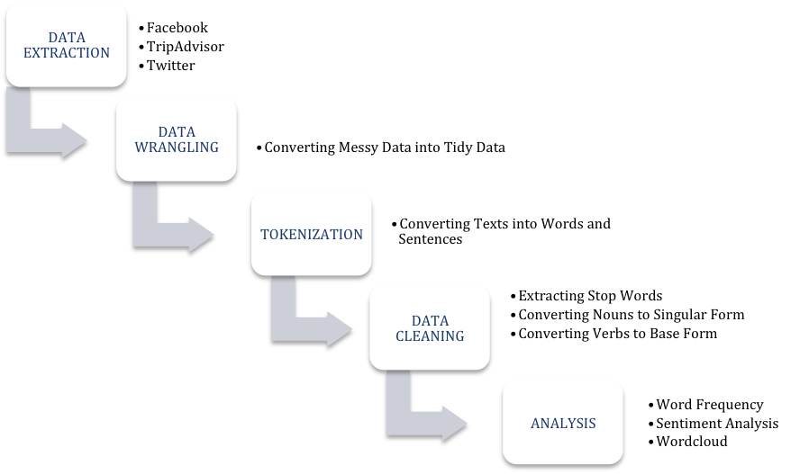

Methodology

- The study builds reuseable R functions for these techniques.

# Data

# Facebook Data Extraction - Steps

1. Create Facebook App by logging into link
   - The App is used to connect to the Facebook API.
2. Connect R session with Facebook App.
3. Extract Posts Data from the Facebook Page.
4. Extract Comments using Posts’ IDs.
5. Joining Comments Data with Posts Data.

# Facebook Data Extraction - Code

```r
# Facebook Authorization
fb_oauth <- Rfacebook::fbOAuth(
  app_id="1380496555352781",
  app_secret="eb3abc...",
  extended_permissions = TRUE)

# Saving variable fb_oauth
save(fb_oauth, file="fb_oauth")

# Extract posts from turkish airlines page
turkishairlines <-
  Rfacebook::getPage(
    page = "turkishairlines",
    token = fb_oauth, n = 2000)

# Save the posts in R data file
saveRDS(turkishairlines, "turkishairlines_2000")
```

# Facebook Data Extraction - Output

```
## # A tibble: 5 x 6
##   from_id     likes_count type  comments_count shares_count message
##   <chr>             <dbl> <chr>          <dbl>        <dbl> <chr>
## 1 90430042759         254 photo             12           18 Our flights t…
## 2 90430042759         300 photo            132           92 "We are looki…
## 3 90430042759         869 photo             39           43 The most plea…
## 4 90430042759         261 photo              9            7 Famous actor …
## 5 90430042759         227 photo             13           11 Within the sc…
```

- Selecting the `message` column in the dataframe.

```r
data_turkishairlines %>%
  dplyr::select(message) %>%
  tibble::as_tibble() %>%
  head(5)
```

```
## # A tibble: 5 x 1
##   message
##   <chr>
## 1 Our flights to Samarkand start on March 16th, 2018!
## 2 "We are looking for new pilots! Join us at Turkish Airlines Pilot Roads…
## 3 The most pleasant journeys start with a warm cup of coffee. Happy #Inte…
## 4 Famous actor Nikolaj Coster-Waldau who plays Jaime in Game of Thrones, …
## 5 Within the scope of our Exclusive Drive service, you’ll feel privileged…
```

# Facebook Data Extraction - Code

- `lapply` function is used to call a function for each element in a vector.
- The function saves the output from each elements into a separate vector.
- `getPost` function is called for 300 posts’ IDs.
- The comments for each post is stored in 300 different lists.

```r
# Extracting comments and reactions from the extracted posts
all_posts <- data_turkishairlines_id[1:300] %>%
  lapply(getPost, n = 50000, token=fb_oauth,
         comments = TRUE, reactions = TRUE)

# Save first 300 posts comments in a R data file.
saveRDS(all_posts, "300_posts")
```

# Facebook Data Extraction - Code

- Reading the saved RDS file instead of applying getPost function repeatedly.

```r
threehundred_posts <- readRDS("300_posts")
```

- For loop that extracts comments from the list and save it in a dataframe with respective ID.

```r
for (i in 1:299) {
  comment <- threehundred_posts[[i+1]]$comments$message %>%
    as.data.frame() %>%
    setNames("comments") %>%
    dplyr::mutate(id = data_turkishairlines_id[i+1])
  full_comments = rbind(full_comments, comment)
}
```

- Joining Post data with comments and save it in database.

```r
# Joining Post data with comments.
full_comment_post <- full_comments %>%
  dplyr::left_join(data_turkishairlines, by = "id")

# Saving the comments of posts in R data file.
saveRDS(full_comment_post, "300_posts_comments")
```

# Facebook Data Extraction - Output

- New column `comments` has been added to the dataframe.

```
## # A tibble: 5 x 10
##   from_id  comments    id    from_name message  created_time type  link
##   <chr>    <fct>       <chr> <chr>     <chr>    <chr>        <chr> <chr>
## 1 9043004… Direct fli… 9043… Turkish … Our fli… 2017-10-05T… photo https:…
## 2 9043004… Just curio… 9043… Turkish … Our fli… 2017-10-05T… photo https:…
## 3 9043004… What about… 9043… Turkish … Our fli… 2017-10-05T… photo https:…
## 4 9043004… What about… 9043… Turkish … Our fli… 2017-10-05T… photo https:…
## 5 9043004… Very inter… 9043… Turkish … Our fli… 2017-10-05T… photo https:…
## # ... with 2 more variables: likes_count <dbl>, comments_count <dbl>
```

- The comments column is expanded using `select` function.

```
## # A tibble: 5 x 1
##   comments
##   <fct>
## 1 Direct flight from Ireland to bodrum badly needed even twice a week in …
## 2 Just curious you do flights to Tbilisi?
## 3 What about fligths to faisalabad in Pakistan
## 4 What about LFW in Togo ?
## 5 Very interesting and beautiful, I have been there. The whole Uzbekistan…
```

# TripAdvisor Data Extraction - Code

- WebScraping is done through package `rvest`

```r
library("rvest")

url <- "https://www.tripadvisor.com/Airline_Review-d8729174-Reviews-Turkish-Airlines"
url <- "https://www.tripadvisor.com/Airline_Review-d8729174-Reviews-or20-Turkish-Airlines#REVIEWS"

df_total = data.frame()

for (i in seq(0, 20050, 10))
{
  if (i == 0) {
    url <- "https://www.tripadvisor.com/Airline_Review-d8729069-Reviews-Emirates"
  }

  else  {
    url <- paste(
      "https://www.tripadvisor.com/Airline_Review-d8729069-Reviews-or",i,"-Emirates#REVIEWS",
      sep = "")
  }

  reviews <- url %>%
    read_html() %>%
    html_nodes("#REVIEWS .innerBubble")

  id <- reviews %>%
    html_node(".quote a") %>%
    html_attr("id")

  quote <- reviews %>%
    html_node(".quote span") %>%
    html_text()

  rating <- reviews %>%
    html_node(".rating .rating_s_fill") %>%
    html_attr("alt") %>%
    gsub(" of 5 stars", "", .) %>%
    as.integer()

  date <- reviews %>%
    html_node(".rating .ratingDate") %>%
    html_attr("title") %>%
    strptime("%b %d, %Y") %>%
    as.POSIXct()

  review <- reviews %>%
    html_node(".entry .partial_entry") %>%
    html_text()

  df <- data.frame(id, quote, rating, date, review, stringsAsFactors = FALSE)
  df_total <- rbind(df_total, df)
}

# Save an object to a file
saveRDS(df_total, file = "tripadvisor_turkishairlines6846.rds")
```

# TripAdvisor Data Extraction - Output

- First five rows of a dataframe is shown using `head` function

```
## # A tibble: 5 x 4
##   id          date                quote      review
##   <chr>       <dttm>              <chr>      <chr>
## 1 rn575914601 2018-04-26 00:00:00 Never aga… "\nTo start with me and my s…
## 2 rn575863809 2018-04-26 00:00:00 Istanbul … "\nTurkish airlines is the b…
## 3 rn575859234 2018-04-26 00:00:00 Broke my … "\nTravelled from Ataturk to…
## 4 rn575854758 2018-04-26 00:00:00 comfortab… "\nit is amazing travelling …
## 5 rn575817214 2018-04-26 00:00:00 Despite h… "\nAlways like travelling on…
```

- The review column is expanded using `select` function.

[output not shown]

# Data Wrangling

- It is said that 80 percent of data analysis effort is spend in the process of preparing and tidying data (Dasu and Johnson 2003).
- The extracted social media data is in raw format and huge amount of effort is required to clean before getting it ready for analysis.
- Through effective data wrangling, the data is converted from raw format to another format that is easy to clean, manipulate, model and visualize.
- Hadley Wickham (2014) provides an effective way of data wrangling data through which messy datasets are converted into tidy datasets by using only small set of tools.
- The tidy datasets have a specific data structure:
  - each variable is a column
  - each observation is a row
  - each observational unit is a table
- Tidy data sets are obtained and manipulated through a set of tidy tools, including famous packages
  - `dplyr` (Wickham et al. 2017)
  - `ggplot2` (Wickham, ggplot2: Elegant Graphics for Data Analysis 2009)
  - `tidyr` (Wickham and Henry, tidyr: Easily Tidy Data with ‘spread()’ and ‘gather()’ Functions 2018)
  - `broom` (Robinson 2018).

# Tokenization - Steps

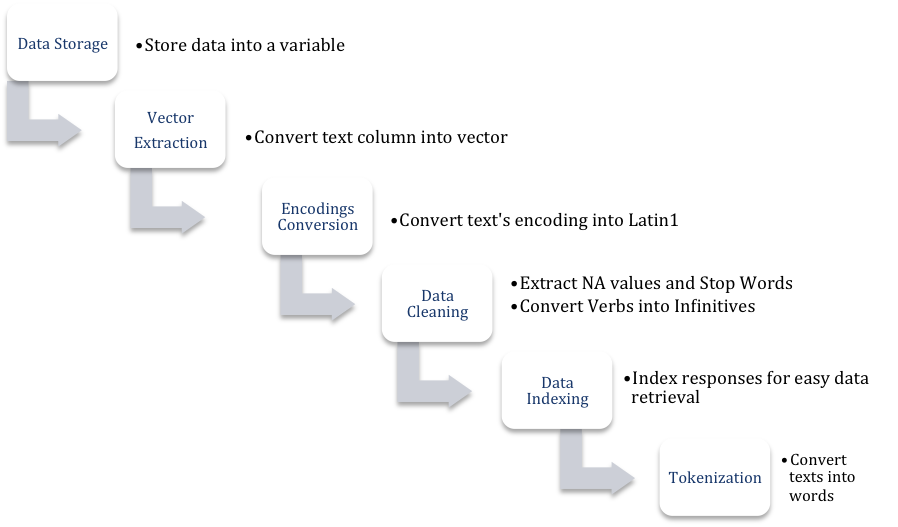

Tokenization

# Tokenization - Code

```r
tokenize <- function(file, data_type) {
  data_tibble <- readRDS(file = file) %>%
    tibble::as_tibble()

  data_vector <- data_tibble %>%
    dplyr::pull(data_type) %>%
    iconv(from = "UTF-8", to = "Latin1")

  tokens <- tibble::as_tibble(data_vector) %>%
    dplyr::filter(!is.na(value)) %>%
    dplyr::mutate(response_number = rownames(.)) %>%
    dplyr::select(response_number, value) %>%
    tidytext::unnest_tokens(word, value)

  tokens
}
```

# Data Cleaning - Steps

- Extract NA Values
  - Conversion of encoding from `UTF8` to `Latin1`, NA values are generated.
- Extract Stop Words
  - Stop words are natural language words which have very little meaning, such as “and”, “the”, “a”, “an”, and similar words
- Convert verbs into base form
  - Verbs like *fly*, *flew* and *flown* are converted into base form *fly*.
- Convert nouns into singular form
  - Nouns like *flights* and *aircrafts* and converted to *flight* and *aircraft* respectively.

# Stop words Cleaning - Code

- Package `tidytext` contains a list of stop words.

```r
library(tidytext)
data(stop_words)

stop_words %>%
  dplyr::sample_n(5)
```

```
## # A tibble: 5 x 2
##   word  lexicon
##   <chr> <chr>
## 1 the   snowball
## 2 per   SMART
## 3 in    snowball
## 4 had   snowball
## 5 faces onix
```

- New stop words can be added to the stop_words lexicon.
- Words like, “flight”, “turkish” and “airlines” are added to the `stop_words` data.

```r
# Custom stop words
custom_stop_words <- data.frame(word = c("miss", "flight", "tukish",
                                         "airlines", "flights",
                                         "airline", "turkish", "de"),
                                lexicon = c("custom")) %>%
  rbind(stop_words)
```

# Base Verbs

- The tokens include multiple forms of verbs that are considered different words during analysis.
- Study converts verbs in different forms, including present simple, past simple, present participle and past participle into base form of verbs
- There is not any specific package in R that converts verbs from different forms into base form.
- The study develops its own lexicon of verbs with its other forms of verbs.
- The lexicon is named as *sahban base lexicon* and saved along with other datasets in the `.rda` format.
- The lexicon contains a total of 2,154 different verbs.
- The lexicon data have two columns, base column, refers to the base form of verbs, and non_base column, refers to all forms of verbs other than base form.
- The study provides a function extract_non_base that converts the other verb forms tokens into base form verbs.

```r
# Convert non_base verbs into base verbs
extract_non_base <- function(data) {
  data %>%
    dplyr::rename(non_base = word) %>%
    dplyr::left_join(readRDS("sahban_base_lexicon"), by = "non_base") %>%
    dplyr::mutate(base = ifelse(is.na(base), non_base, base)) %>%
    dplyr::rename(word = base) %>%
    dplyr::select(-one_of("non_base"))
}
```

# Singular Noun

- The tokens include plural nouns that are considered different words than their respective singular nouns during analysis.
- The study converts plural nouns into singular form of nouns.
- There is not any specific package in R that deals with the issue of converting nouns from plural to singular form.
- The study develops its own lexicon of nouns with its plural forms.
- The lexicon is named as sahban_noun_lexicon and saved along with other datasets.
- The lexicon contains a total of 4,489 different nouns.
- The lexicon data have two columns, noun column, refers to the singular form of nouns, and plural column, which refers to plural form of nouns.
- Furthermore, the study provides a function extract_plural that converts the plural noun tokens into singular form.

```r
# Convert Plurals to Singular Noun
extract_plural <- function(data) {
  data %>%
    dplyr::rename(plural = word) %>%
    dplyr::left_join(readRDS("sahban_noun_lexicon"), by = "plural") %>%
    dplyr::mutate(noun = ifelse(is.na(noun), plural, noun)) %>%
    dplyr::rename(word = noun) %>%
    dplyr::select(-one_of("plural"))
}
```